# Data Visualization : In-class Materials

Mari hilangkan legend Freq karena sudah ditampilkan pada geom_text, dan channel_title karena sudah diinformasikan pada title dan axis text nya.

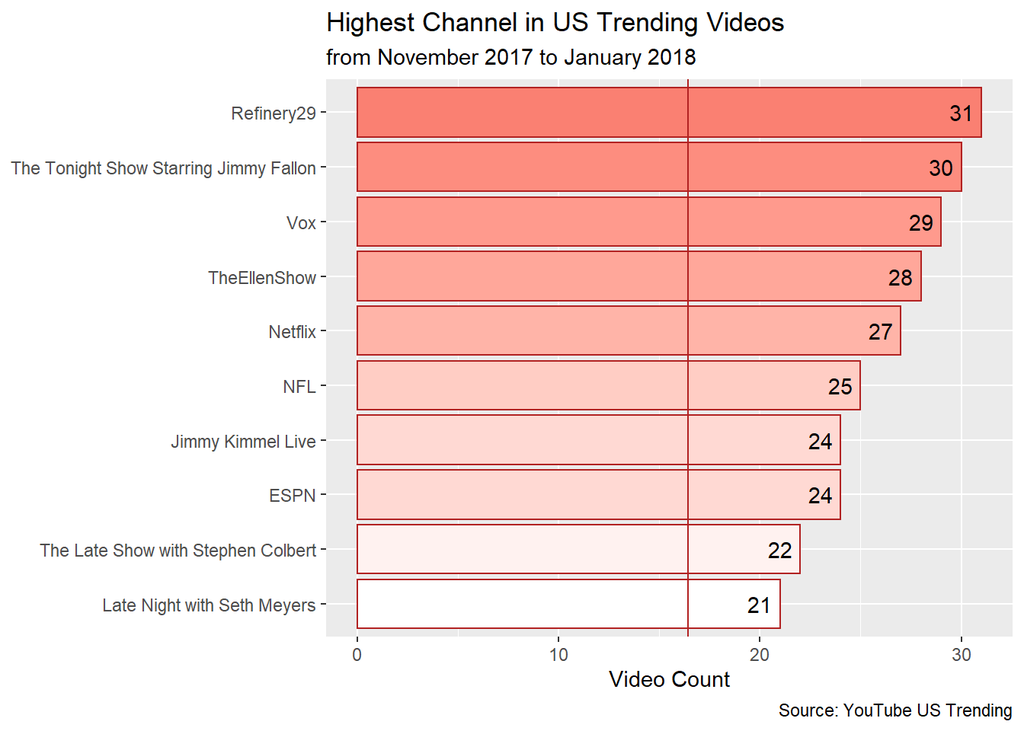

```r
ggplot(data = vids.chan[1:10,], mapping = aes(x = Freq, y = reorder(Var1, Freq))) +
  geom_col(mapping = aes(fill = Freq), col = "firebrick",
           show.legend = F) + # agar legend dari geom ini (fill) tidak ditampilkan
  scale_fill_gradient(low = "white", high = "salmon") +
  geom_vline(xintercept = mean(vids.chan$Freq), col = "firebrick") +
  geom_text(aes(label = Freq), nudge_x = -1) +
  labs(title = "Highest Channel in US Trending Videos",
       subtitle = "from November 2017 to January 2018",
       x = "Video Count",
       y = NULL, # untuk menghilangkan labs tertentu
       caption = "Source: YouTube US Trending")
```

- menambahkan warna lain pada barplot untuk top 3:

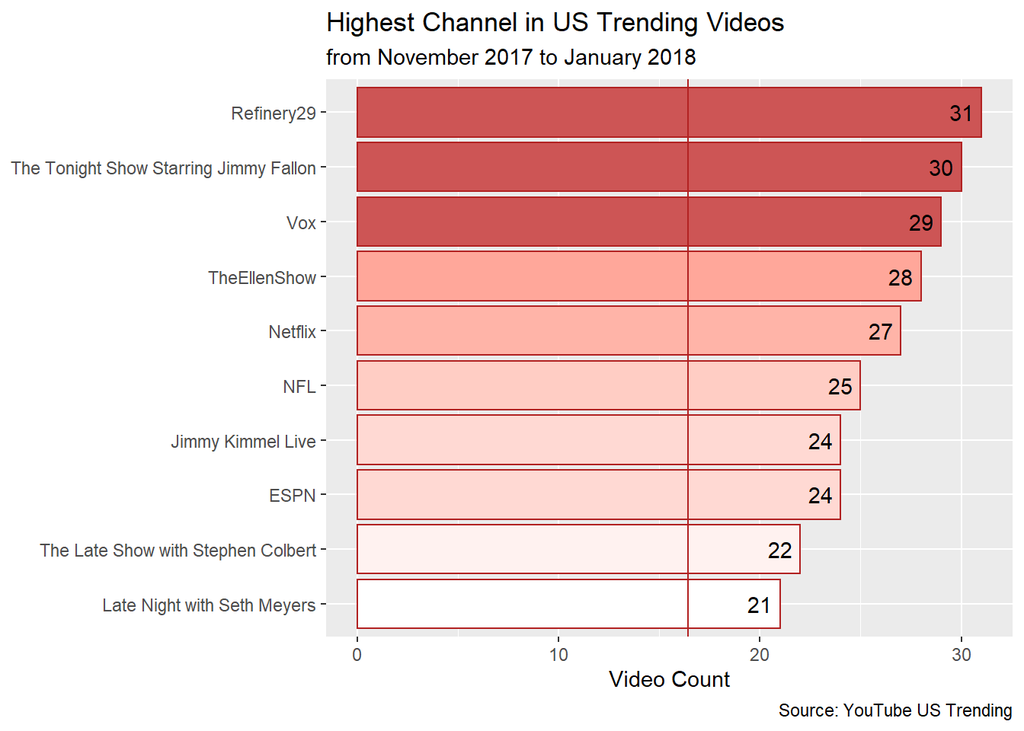

```r
ggplot(data = vids.chan[1:10,], mapping = aes(x = Freq, y = reorder(Var1, Freq))) +
  geom_col(mapping = aes(fill = Freq), col = "firebrick", show.legend = F) +
  geom_col(fill = "indianred3", col = "firebrick", # buat geom_col baru saja (di layer baru)
           data = vids.chan[1:3,]) + # bisa kasih data berbeda; gunakan hanya top 3 sesuai keinginan
  scale_fill_gradient(low = "white", high = "salmon") +
  geom_vline(xintercept = mean(vids.chan$Freq), col = "firebrick") +
  geom_text(aes(label = Freq), nudge_x = -1) +
  labs(title = "Highest Channel in US Trending Videos",
       subtitle = "from November 2017 to January 2018",
       x = "Video Count", y = NULL,
       caption = "Source: YouTube US Trending")
```

- menggunakan theme_minimal (theme bawaan ggplot2)

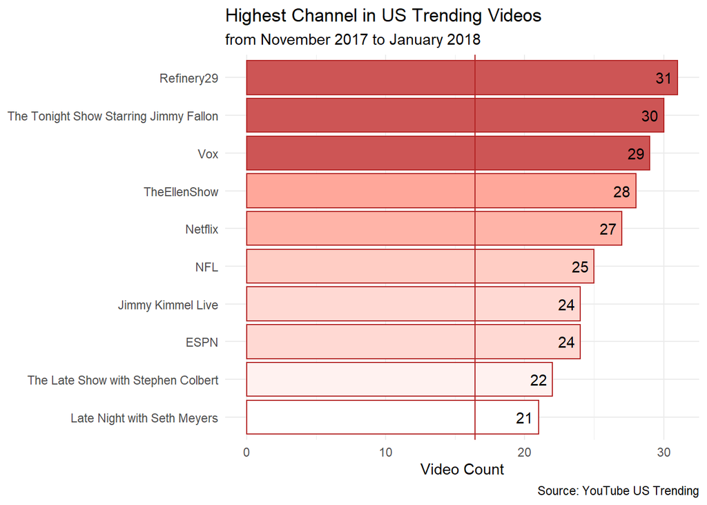

```r
ggplot(data = vids.chan[1:10,], mapping = aes(x = Freq, y = reorder(Var1, Freq))) +
  geom_col(mapping = aes(fill = Freq), col = "firebrick", show.legend = F) +
  geom_col(fill = "indianred3", col = "firebrick", # buat geom_col baru saja (di layer baru)
           data = vids.chan[1:3,]) + # bisa kasih data berbeda; gunakan hanya top 3 sesuai keinginan
  scale_fill_gradient(low = "white", high = "salmon") +
  geom_vline(xintercept = mean(vids.chan$Freq), col = "firebrick") +
  geom_text(aes(label = Freq), nudge_x = -1) +
  labs(title = "Highest Channel in US Trending Videos",
       subtitle = "from November 2017 to January 2018",
       x = "Video Count",
       y = NULL, # untuk menghilangkan labs tertentu
       caption = "Source: YouTube US Trending") +
  theme_minimal()
```

- mengatur gradasi warna pada top 3 (PR):

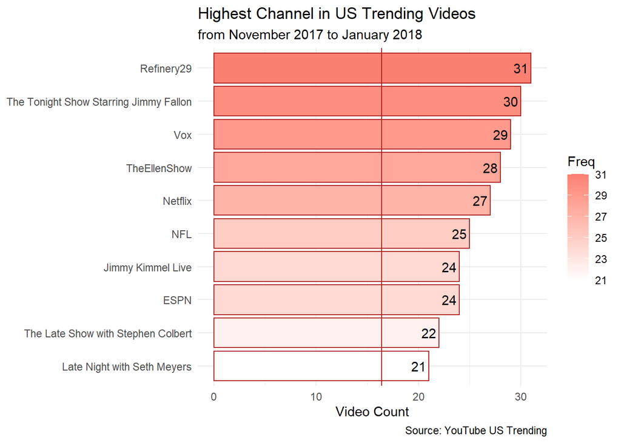

```r
ggplot(data = vids.chan[1:10,], mapping = aes(x = Freq, y = reorder(Var1, Freq))) +
  geom_col(mapping = aes(fill = Freq), col = "firebrick", show.legend = F) +
  geom_col(aes(fill = Freq), col = "firebrick",
           data = vids.chan[1:3,]) +
  scale_fill_gradient(low = "white", high = "salmon") +
  geom_vline(xintercept = mean(vids.chan$Freq), col = "firebrick") +
  geom_text(aes(label = Freq), nudge_x = -1) +
  labs(title = "Highest Channel in US Trending Videos",
       subtitle = "from November 2017 to January 2018",
       x = "Video Count",
       y = NULL, # untuk menghilangkan labs tertentu
       caption = "Source: YouTube US Trending") +
  theme_minimal()
```

Insight:

- content channel YouTube US tertinggi adalah Refinery29
- channel film lebih diminati dr channel olahraga :)

**PR Instructor:**

- menambahkan text berisi informasi rata-rata Freq, disandingkan dengan vline

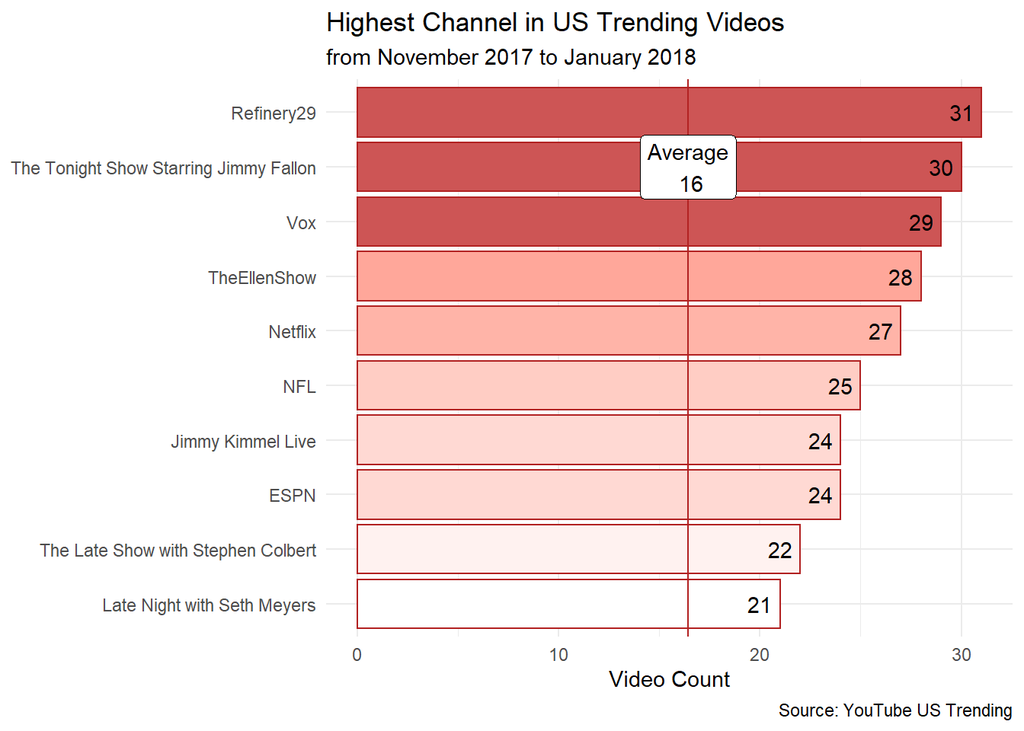

```r
ggplot(data = vids.chan[1:10,], mapping = aes(x = Freq, y = reorder(Var1, Freq))) +
  geom_col(mapping = aes(fill = Freq), col = "firebrick", show.legend = F) +
  geom_col(fill = "indianred3", col = "firebrick", data = vids.chan[1:3,]) +
  scale_fill_gradient(low = "white", high = "salmon") +
  geom_vline(xintercept = mean(vids.chan$Freq), col = "firebrick") +
  geom_text(aes(label = Freq), nudge_x = -1) +

  # tambah label
  geom_label(label = paste("Average\n", round(mean(vids.chan$Freq))), # isi label
            x = mean(vids.chan$Freq), # posisi x label
            y = 9) + # posisi y label

  labs(title = "Highest Channel in US Trending Videos",
       subtitle = "from November 2017 to January 2018",
       x = "Video Count", y = NULL,
       caption = "Source: YouTube US Trending") +
  theme_minimal()
```

- mengatur title y-axis “Channel Title” di Top Kiri, horizontal:

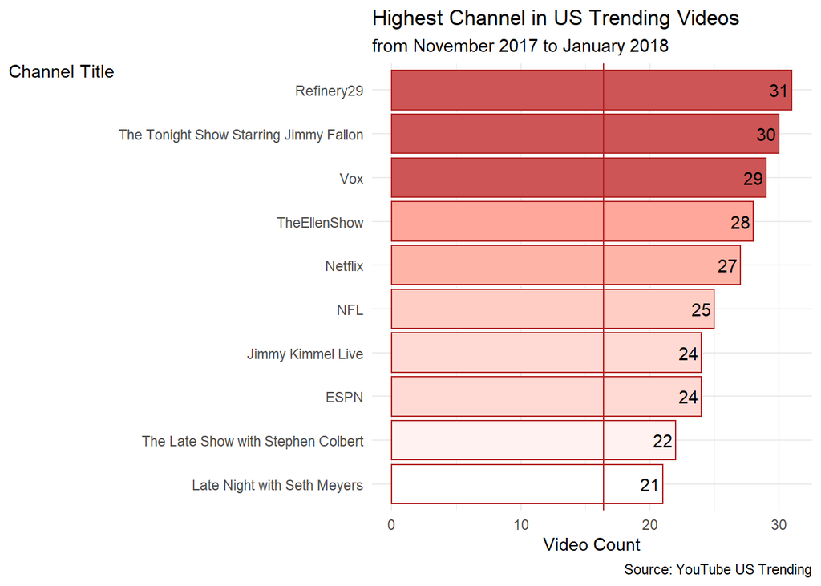

```r
ggplot(data = vids.chan[1:10,], mapping = aes(x = Freq, y = reorder(Var1, Freq))) +
  geom_col(mapping = aes(fill = Freq), col = "firebrick", show.legend = F) +
  geom_col(fill = "indianred3", col = "firebrick", # buat geom_col baru saja (di layer baru)
           data = vids.chan[1:3,]) + # bisa kasih data berbeda; gunakan hanya top 3 sesuai keinginan
  scale_fill_gradient(low = "white", high = "salmon") +
  geom_vline(xintercept = mean(vids.chan$Freq), col = "firebrick") +
  geom_text(aes(label = Freq), nudge_x = -1) +
  labs(title = "Highest Channel in US Trending Videos",
       subtitle = "from November 2017 to January 2018",
       x = "Video Count", y = "Channel Title",
       caption = "Source: YouTube US Trending") +
  theme_minimal() +
  theme(axis.title.y = element_text(angle = 0))
```

Hal di atas bisa dilakukan namun masih terlihat kurang rapih/ada bagian plot yang kosong. Bila ingin tetap ada “Channel Title” pada bagian atas axis text y, bisa melakukan trik untuk plot sebagai berikut ([Referensi Diskusi](https://data-hacks.com/how-add-text-outside-ggplot2-plot-borders-r)):

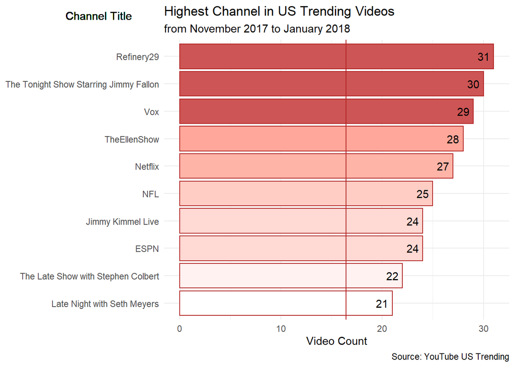

```r
ggplot(data = vids.chan[1:10,], mapping = aes(x = Freq, y = reorder(Var1, Freq))) +
  geom_col(mapping = aes(fill = Freq), col = "firebrick", show.legend = F) +
  geom_col(fill = "indianred3", col = "firebrick", data = vids.chan[1:3,]) +
  scale_fill_gradient(low = "white", high = "salmon") +
  geom_vline(xintercept = mean(vids.chan$Freq), col = "firebrick") +
  geom_text(aes(label = Freq), nudge_x = -1) +

  # menambah text dan menggambar diluar area plot (lihat posisi x & y nya)
  geom_text(label = "Channel Title", x = -8, y = 11.5) +
  # mengatur setting koordinat x & y
  coord_cartesian(clip = "off") + # agar bisa menggambar diluar area plot, defaultnya "yes"

  labs(title = "Highest Channel in US Trending Videos",
       subtitle = "from November 2017 to January 2018",
       x = "Video Count", y = NULL,
       caption = "Source: YouTube US Trending") +
  theme_minimal()
```

**Note:** Bila ingin kostumisasi theme lebih detail dan manual dapat menggunakan `theme()`. Fungsi tersebut mengatur bagian non-data dari plot dan dapat dipilih bagian plot mana yang ingin diatur (lihat peta plot pada ppt “DV_intro”).

**Important points:**

1. Pasangkan nama fungsi dan kegunaannya di bawah ini:
- `geom_col`: membuat barplot (variable kategorik vs variabel numerik)
- `reorder()`: untuk mengurutkan levels (kategori) berdasarkan nilai tertentu (numerik)
- `geom_text`: menambah text pada plot
- `geom_label`: menambah label (text dengan background) pada plot
- `scale_fill_*`: mengatur warna fill
2. Note pembuatan plot:
- kita dapat memasukan data baru ke `geom_*` untuk membuat visual yang datanya berbeda/lebih spesifik dari data awal di `ggplot()`
- banyak fungsi `scale_*` lain (color, fill, x, y, dll) yang dapat dieksplor di cheatsheet
- kostumisasi tema dapat diatur di `theme()` atau menggunakan tema bawaan/package tambahan

**Dive Deeper PR!**:

Visualisasikan 15 channel dengan jumlah video trending tertinggi, highlight 5 channel teratas dengan warna yang berbeda. Berikan elemen-elemen lain untuk mempercantik plot.

## Multivariate Plot

Multivariate plot berguna untuk **menampilkan nilai dari beragam variabel secara bersamaan**.

**Business Question:**

Mari lihat persebaran likes/view yang dimiliki masing-masing kategori video di bawah ini:

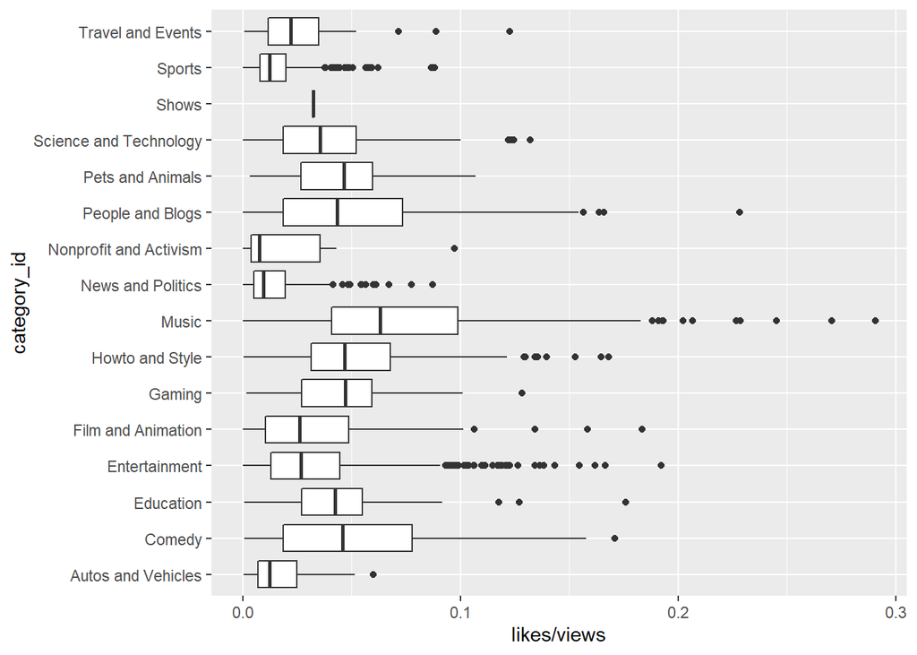

```r
# exploratory data
ggplot(data = vids.u, mapping = aes(x = likes/views, y = category_id)) +
  geom_boxplot()
```

Kita mengetahui bahwa dari keseluruhan kategori, **Music**, **Comedy**, dan **Howto and Style** memiliki likes per view tertinggi. Mari kita lihat lebih detail bagaimana rata-rata **likes/view**, **dislikes/view**, dan **comment/view** dari ketiga kategori tersebut?

**Tahapan:**

1. **Siapkan data**

```r
# subset data dan simpan ke objek `vids.mul`
vids.mul <- vids.u[vids.u$category_id %in% c("Music", "Comedy", "Howto and Style"),]

# drop levels
vids.mul$category_id <- droplevels(vids.mul$category_id) # membuang levels yang tidak ada pada data

# cek data
head(vids.mul)
```

|  | trending_date | title | channel_title | category_id | publish_time | views | likes | dislikes | comment_count | comments_disabled | ratings_disabled | video_error_or_removed | publish_hour | publish_when | publish_wday |
| --- | --- | --- | --- | --- | --- | --- | --- | --- | --- | --- | --- | --- | --- | --- | --- |
| 3 | 2017-11-14 | Racist Superman \| Rudy Mancuso, King Bach & Lele Pons | Rudy Mancuso | Comedy | 2017-11-12 14:05:24 | 3191434 | 146033 | 5339 | 8181 | FALSE | FALSE | FALSE | 14 | 8am to 4pm | Sunday |
| 13 | 2017-11-14 | Marshmello - Blocks (Official Music Video) | marshmello | Music | 2017-11-13 12:00:00 | 687582 | 114188 | 1333 | 8371 | FALSE | FALSE | FALSE | 12 | 8am to 4pm | Monday |
| 17 | 2017-11-14 | One Change That Would Make Pacific Rim a Classic | Cracked | Comedy | 2017-11-12 12:00:05 | 295639 | 8011 | 638 | 1256 | FALSE | FALSE | FALSE | 12 | 8am to 4pm | Sunday |
| 24 | 2017-11-14 | What $4,800 Will Get You In NYC \| Sweet Digs Home Tour \| Refinery29 | Refinery29 | Howto and Style | 2017-11-12 11:00:01 | 145921 | 1707 | 578 | 673 | FALSE | FALSE | FALSE | 11 | 8am to 4pm | Sunday |
| 25 | 2017-11-14 | Using Other People's Showers | Gus Johnson | Comedy | 2017-11-13 09:44:24 | 33980 | 4884 | 52 | 234 | FALSE | FALSE | FALSE | 9 | 8am to 4pm | Monday |
| 28 | 2017-11-14 | A Smart... MUG?! - Take apart a Heated Thermos! | JerryRigEverything | Howto and Style | 2017-11-13 11:00:03 | 120727 | 9033 | 224 | 1346 | FALSE | FALSE | FALSE | 11 | 8am to 4pm | Monday |

```r
# buat kolom
vids.mul$likesp <- vids.mul$likes/vids.mul$views
vids.mul$dislikesp <- vids.mul$dislikes/vids.mul$views
vids.mul$commentp <- vids.mul$comment_count/vids.mul$views
```

```r
# aggregasi data; rata-rata likesp, dislikesp, commentp untuk tiap category_id
vids.mulagg <- aggregate.data.frame(list(dislikesp = vids.mul$dislikesp, # kolom yang ingin diaggregasi
                                         likesp = vids.mul$likesp,
                                         commentp = vids.mul$commentp),
                                    by = list(category = vids.mul$category_id), # aggregasi berdasarkan apa
                                    FUN = mean)

vids.mulagg
```

| category | dislikesp | likesp | commentp |
| --- | --- | --- | --- |
| Comedy | 0.001384602 | 0.05224843 | 0.005728204 |
| Howto and Style | 0.001467801 | 0.05235849 | 0.007602683 |
| Music | 0.001711663 | 0.07237631 | 0.006829053 |

```r
# transform data wide -> long
library(tidyr)

vids.pivot <- pivot_longer(data = vids.mulagg,
             cols = c("dislikesp", "likesp", "commentp"), # kolom yang ingin di gabung jadi long format
             names_to = "stats", values_to = "nilai") # nama kolom menjadi ...
vids.pivot
```

| category | stats | nilai |
| --- | --- | --- |
| Comedy | dislikesp | 0.001384602 |
| Comedy | likesp | 0.052248431 |
| Comedy | commentp | 0.005728204 |
| Howto and Style | dislikesp | 0.001467801 |
| Howto and Style | likesp | 0.052358488 |
| Howto and Style | commentp | 0.007602683 |
| Music | dislikesp | 0.001711663 |
| Music | likesp | 0.072376313 |
| Music | commentp | 0.006829053 |

2. **Visualisasi data**

Multivariate plot dapat dibuat menggunakan `geom_col()` dengan mengatur `position`:

- **dodge** = menampilkan nilai asli -> untuk membandingkan nilai asli
- **fill** = menampilkan proporsi -> untuk memandingkan proporsi
- **stack** = untuk menampilkan nilai asli dan proporsi (default) -> melihat nilai asli sekaligus membandingkan proporsi

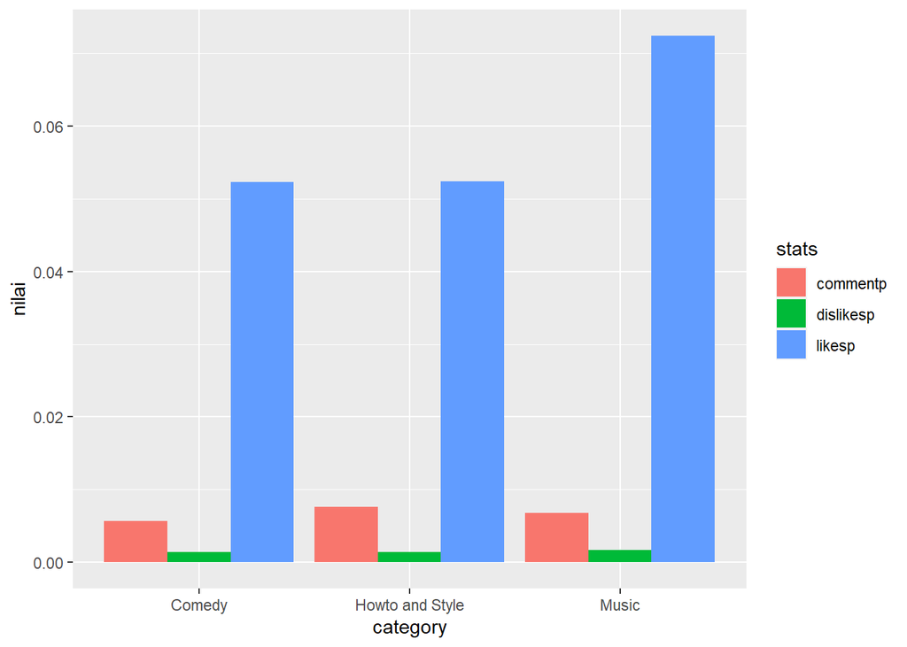

```r
ggplot(data = vids.pivot, mapping = aes(x = category, y = nilai)) +
  geom_col(mapping = aes(fill = stats),
           position = "dodge")
```

Insight:

- likesp tertinggi dimiliki oleh music
- commentp tertinggi dimiliki oleh Howto and Style

**Contoh Position Lain**

**Business Question:** Ingin menvisualisasi proporsi video yang di publish pada waktu tertentu (`publish_when`) untuk tiap kategori.

```r
# siapkan data
vids.mul2 <- as.data.frame(table(vids.u$category_id,
                                 vids.u$publish_when))
vids.mul2 # data sudah dalam bentuk long
```

| Var1 | Var2 | Freq |
| --- | --- | --- |
| Autos and Vehicles | 12am to 8am | 6 |
| Comedy | 12am to 8am | 61 |
| Education | 12am to 8am | 4 |
| Entertainment | 12am to 8am | 140 |
| Film and Animation | 12am to 8am | 13 |
| Gaming | 12am to 8am | 2 |
| Howto and Style | 12am to 8am | 26 |
| Music | 12am to 8am | 134 |
| News and Politics | 12am to 8am | 45 |
| Nonprofit and Activism | 12am to 8am | 1 |

[output cut: 38 more lines]

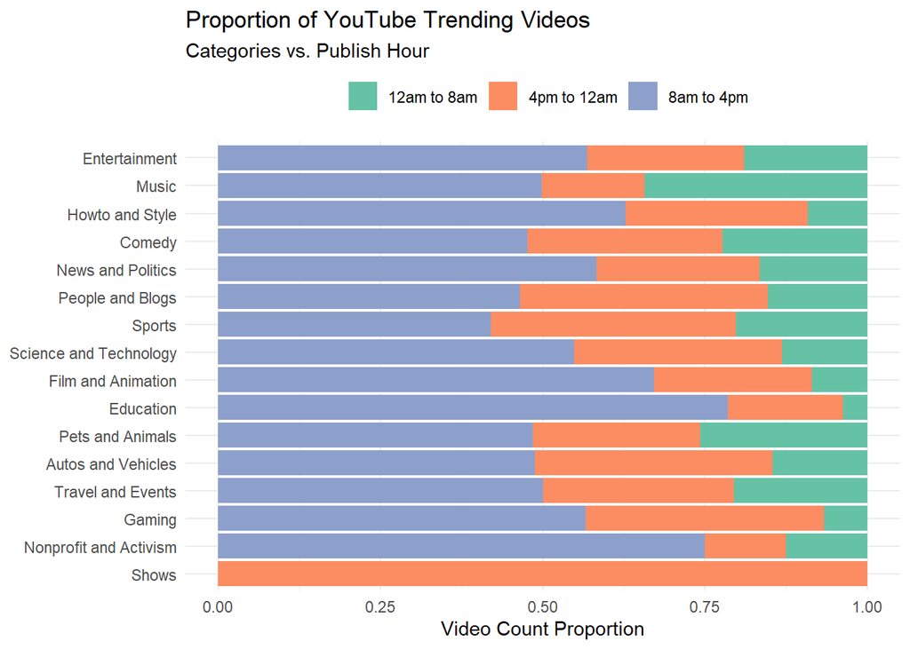

```r
# position fill
ggplot(data = vids.mul2, mapping = aes(x = Freq, y = reorder(Var1, Freq))) +
  geom_col(mapping = aes(fill = Var2), position = "fill") +
  labs(x = "Video Count Proportion", y = NULL,
       fill = NULL,
       title = "Proportion of YouTube Trending Videos",
       subtitle = "Categories vs. Publish Hour") +
  scale_fill_brewer(palette = "Set2") +
  theme_minimal() +
  theme(legend.position = "top")
```

**Insight**:

- Secara umum video banyak di publish pada jam 8am-4pm
- Kategori Shows hanya memiliki video yang dipublish pada jam 4pm-12am

**Contoh Position Lain**

**Business Question:** Kategori video apa yang paling banyak masuk dalam jejeran video trending? Pada jam berapa kebanyakan video dari kategori tersebut dipublish?

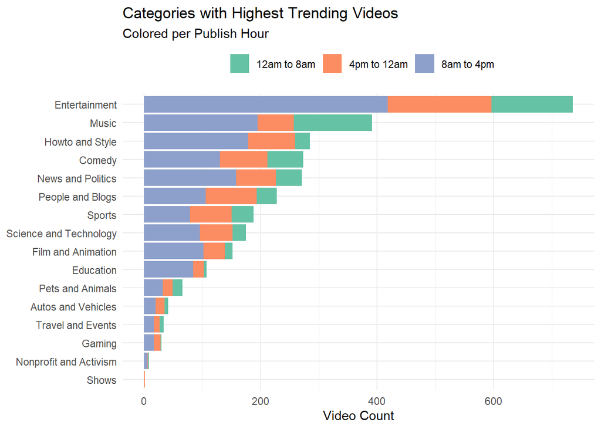

```r
# position stack
ggplot(data = vids.mul2, mapping = aes(x = Freq, y = reorder(Var1, Freq))) +
  geom_col(mapping = aes(fill = Var2), position = "stack") + # default position
  labs(x = "Video Count", y = NULL,
       fill = NULL,
       title = "Categories with Highest Trending Videos",
       subtitle = "Colored per Publish Hour") +
  scale_fill_brewer(palette = "Set2") +
  theme_minimal() +
  theme(legend.position = "top")
```

**Insight**: Category yang videonya masuk ke dalam jejeran video trending terbanyak adalah Entertainment, dengan jam publish video adalah pada jam 8 pagi hingga 4 sore.

## Faceting

Memplotkan variabel di panel terpisah, sehingga visual menjadi lebih jelas.

**Contoh:** Ingin memplotkan secara terpisah **likesp**, **dislikesp**, dan **commentp** per kategori dari data `vids.mul` dengan range axis y yang berbeda (menyesuaikan).

```r
# data
vids.pivot
```

| category | stats | nilai |
| --- | --- | --- |
| Comedy | dislikesp | 0.001384602 |
| Comedy | likesp | 0.052248431 |
| Comedy | commentp | 0.005728204 |
| Howto and Style | dislikesp | 0.001467801 |
| Howto and Style | likesp | 0.052358488 |
| Howto and Style | commentp | 0.007602683 |
| Music | dislikesp | 0.001711663 |
| Music | likesp | 0.072376313 |
| Music | commentp | 0.006829053 |

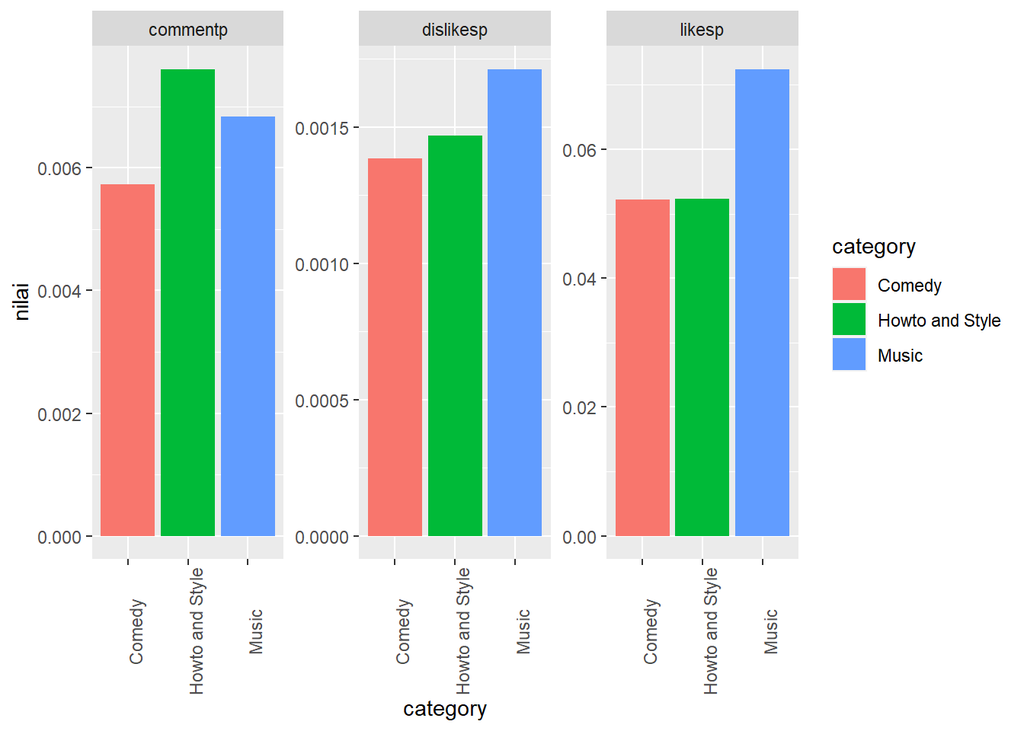

```r
# visualisasi
ggplot(data = vids.pivot, mapping = aes(x = category, y = nilai)) +
  geom_col(mapping = aes(fill = category),
           position = "dodge") +
  facet_wrap(~stats, scales = "free_y") +
  theme(axis.text.x = element_text(angle = 90))
```

## Line Plot

Line plot berguna untuk menvisualisasikan trend.

**Contoh:** Visualisasikan trend **rata-rata viewers** tiap `publish_hour` untuk `category_id` Music, Comedy, Howto and Style!

1. Siapkan data

```r
head(vids.mul)
```

|  | trending_date | title | channel_title | category_id | publish_time | views | likes | dislikes | comment_count | comments_disabled | ratings_disabled | video_error_or_removed | publish_hour | publish_when | publish_wday | likesp | dislikesp | commentp |
| --- | --- | --- | --- | --- | --- | --- | --- | --- | --- | --- | --- | --- | --- | --- | --- | --- | --- | --- |
| 3 | 2017-11-14 | Racist Superman \| Rudy Mancuso, King Bach & Lele Pons | Rudy Mancuso | Comedy | 2017-11-12 14:05:24 | 3191434 | 146033 | 5339 | 8181 | FALSE | FALSE | FALSE | 14 | 8am to 4pm | Sunday | 0.04575780 | 0.001672916 | 0.002563424 |
| 13 | 2017-11-14 | Marshmello - Blocks (Official Music Video) | marshmello | Music | 2017-11-13 12:00:00 | 687582 | 114188 | 1333 | 8371 | FALSE | FALSE | FALSE | 12 | 8am to 4pm | Monday | 0.16607183 | 0.001938678 | 0.012174548 |
| 17 | 2017-11-14 | One Change That Would Make Pacific Rim a Classic | Cracked | Comedy | 2017-11-12 12:00:05 | 295639 | 8011 | 638 | 1256 | FALSE | FALSE | FALSE | 12 | 8am to 4pm | Sunday | 0.02709724 | 0.002158037 | 0.004248425 |
| 24 | 2017-11-14 | What $4,800 Will Get You In NYC \| Sweet Digs Home Tour \| Refinery29 | Refinery29 | Howto and Style | 2017-11-12 11:00:01 | 145921 | 1707 | 578 | 673 | FALSE | FALSE | FALSE | 11 | 8am to 4pm | Sunday | 0.01169811 | 0.003961047 | 0.004612085 |
| 25 | 2017-11-14 | Using Other People's Showers | Gus Johnson | Comedy | 2017-11-13 09:44:24 | 33980 | 4884 | 52 | 234 | FALSE | FALSE | FALSE | 9 | 8am to 4pm | Monday | 0.14373161 | 0.001530312 | 0.006886404 |
| 28 | 2017-11-14 | A Smart... MUG?! - Take apart a Heated Thermos! | JerryRigEverything | Howto and Style | 2017-11-13 11:00:03 | 120727 | 9033 | 224 | 1346 | FALSE | FALSE | FALSE | 11 | 8am to 4pm | Monday | 0.07482171 | 0.001855426 | 0.011149122 |

```r
# aggregate data
vids.trend <- aggregate(formula = views ~ publish_hour + category_id, data = vids.mul, FUN = mean)
vids.trend
```

| publish_hour | category_id | views |
| --- | --- | --- |
| 0 | Comedy | 653175.55 |
| 1 | Comedy | 842107.55 |
| 3 | Comedy | 2765121.00 |
| 4 | Comedy | 572170.00 |
| 5 | Comedy | 425934.57 |
| 6 | Comedy | 278484.76 |
| 7 | Comedy | 161360.11 |
| 8 | Comedy | 179126.33 |
| 9 | Comedy | 507056.00 |
| 10 | Comedy | 262216.38 |

[output cut: 60 more lines]

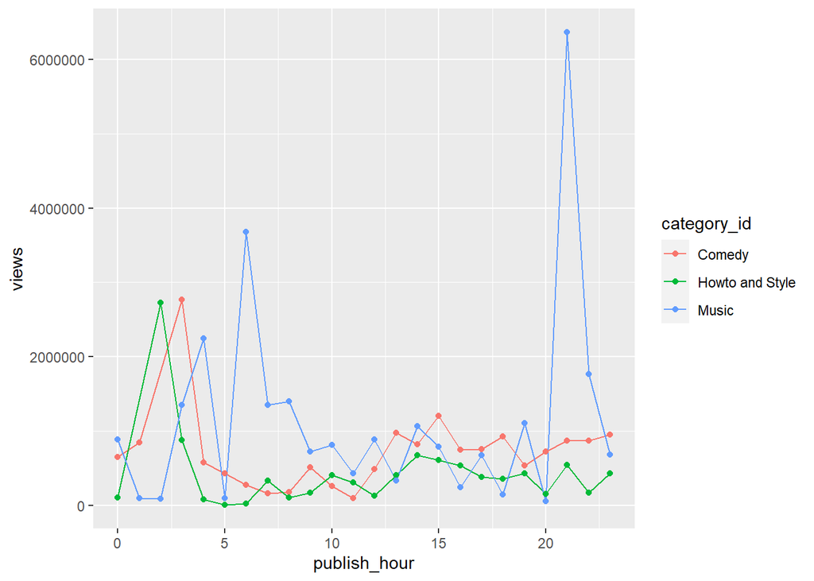

```r
# visualisasi geom_line
ggplot(data = vids.trend, mapping = aes(x = publish_hour, y = views)) +
  geom_line(aes(group = category_id, # group untuk menentukan line dibuat berdasarkan kolom tertentu
                col = category_id)) + # `col` juga bisa langsung dimasukkan ke ggplot() utk diaplikasikan ke semua geom
  geom_point(aes(col = category_id))
```

**Insight**:

- comedy dan howto and style paling banyak dilihat pada dini hari
- Music paling tinggi dilihat pada jam malam hari (21:00)

**Important Points**:

- **Multivariate plot**: untuk menampilkan nilai dari beragam variabel secara bersamaan
- **Faceting**: untuk memplotkan variabel di panel terpisah, sehingga visual menjadi lebih jelas.
- **Line plot**: untuk menvisualisasikan trend. Dapat menggunakan `geom_line()` dan parameter yang khas adalah `group` untuk mengatur grouping line berdasarkan variable/kolom apa.
  - group = nama kolom; bila dibuat garis untuk masing-masing kategori
  - group = 1; bila ingin dibuat 1 line saja

# Theme

Theme bawaan ggplot2:

```r
plot_trend <- ggplot(data = vids.trend, mapping = aes(x = publish_hour, y = views)) +
  geom_line(aes(group = category_id, # group untuk menentukan line dibuat berdasarkan kolom tertentu
                col = category_id)) +
  geom_point(aes(col = category_id))
```

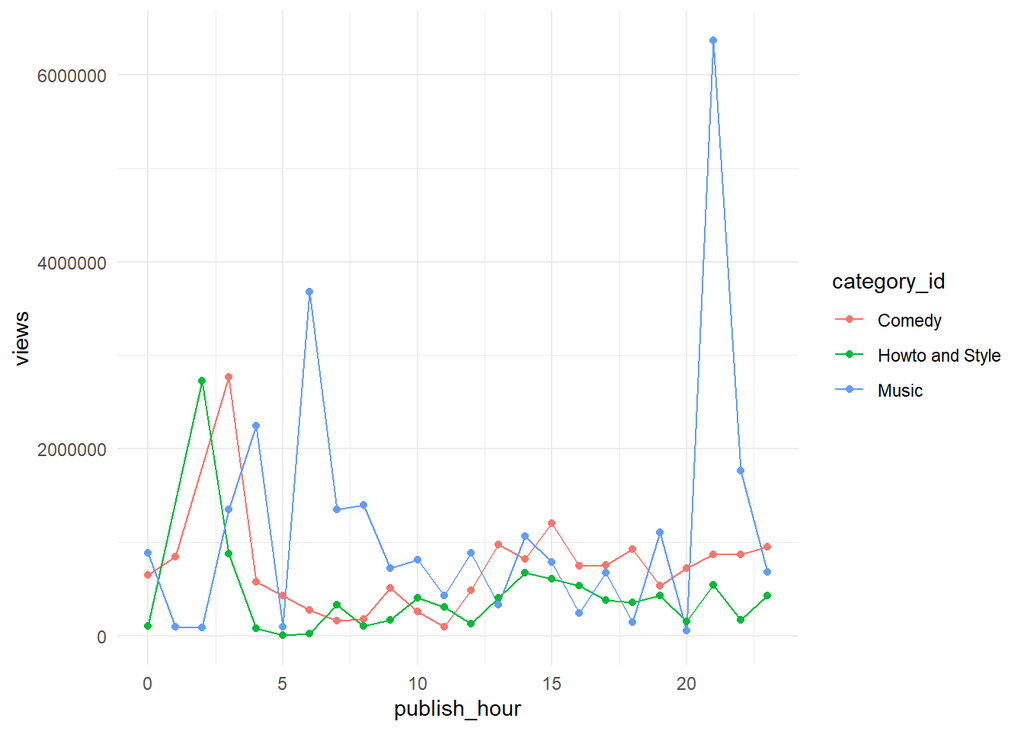

```r
plot_trend + theme_minimal()
```

Customize theme manual menggunakan `theme()`:

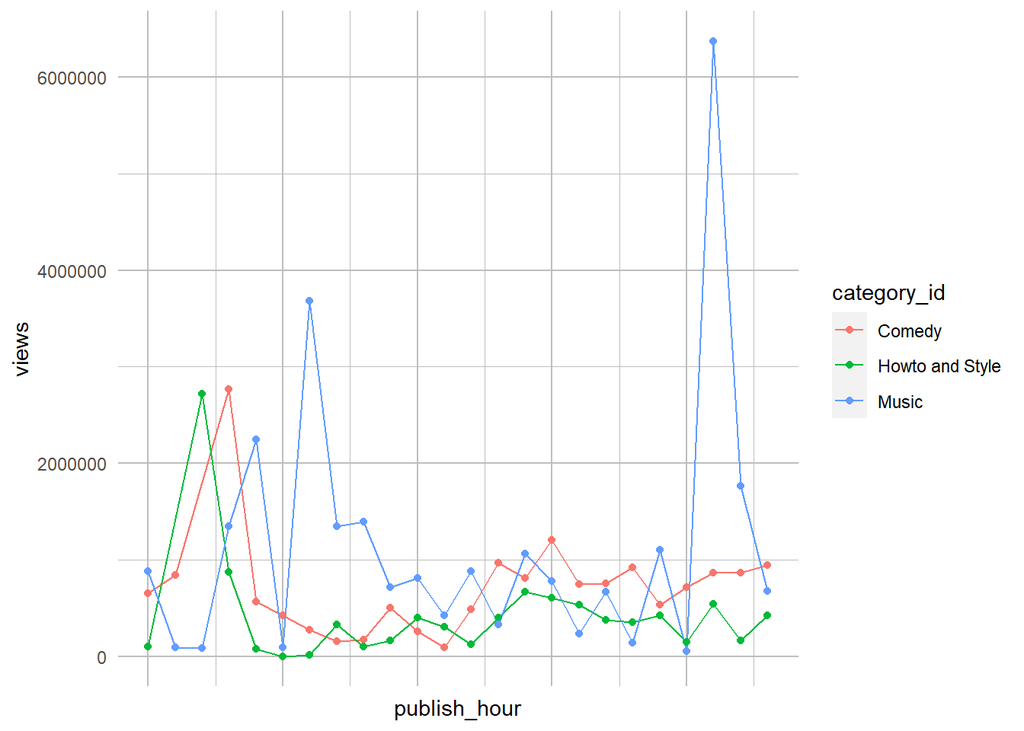

```r
plot_trend +
  # theme_classic() +
  theme(axis.line = element_line(colour = "white"),
        axis.ticks.y = element_blank(),
        axis.ticks.x = element_blank(),
        axis.text.x = element_blank(),

        panel.background = element_rect(fill = "white"),
        panel.grid = element_line(color = "grey"))
```

# [Opt] Interactive Map with `leaflet`

Kita dapat membuat interactive map dengan bantuan package `leaflet`. Leaflet sendiri adalah open-source JavaScript library untuk pembuatan interactive maps.

Contoh sederhana:

```r
library(leaflet)

# get icon
ico <- makeIcon(
    iconUrl = "https://algorit.ma/wp-content/uploads/2017/07/logo_light_trans.png",
    iconWidth=177/2, iconHeight=41/2
)

# make dummy data
set.seed(418)
loca <- data.frame(lat=runif(5, min = -6.24, max=-6.23),
                   lng=runif(5, min=106.835, max=106.85))

# check data
loca
```

| lat | lng |
| --- | --- |
| -6.235811 | 106.8444 |
| -6.233685 | 106.8413 |
| -6.239896 | 106.8448 |
| -6.235132 | 106.8377 |
| -6.237927 | 106.8477 |

```r
# create a leaflet map widget
map1 <- leaflet()

# add tiles from open street map
map1 <- addTiles(map1)

# add markers
map1 <- addMarkers(map1, data = loca, icon=ico)

map1
```

[interactive chart not shown]

```r
# prepare pop-up
pops <- c(
    "<h3>Algoritma Main HQ</h3><p>Visit us here!</p>",
    "<strong>Algoritma Business Campus</strong>",
    "<h3>In-Construction</h3><p>New Secondary Campus</p>",
    "<strong>Secondary Campus</strong>",
    "<strong>The Basecamp (business-school)</strong>"
)
```

```r
# make new leaflet
map2 <- leaflet()
map2 <- addTiles(map2)
map2 <- addMarkers(map2, data = loca, icon=ico, popup = pops)

map2
```

[interactive chart not shown]

Berikut adalah website dan referensi yang dapat mempermudah pemahaman kita mengenai leaflet:

- [Leaflet for R](https://rstudio.github.io/leaflet/)
- [Creating Choropleth Map for Geocoding in R](https://algotech.netlify.com/blog/creating-choropleth-with-mapshaper-and-r/)

# Further Readings

Berikut adalah referensi-referensi lain dan website yang dapat memudahkan kita untuk mengekplorasi seputar data visualisasi di R:

- [ggplot2: Elegant Graphics for Data Analysis by Hadley Wickham](https://ggplot2-book.org/)
- [Data-to-Viz](https://www.data-to-viz.com/): ragam tipe data dan plot yang cocok untuk data tersebut, dilengkapi contoh plot dan coding
- [Algotech - Rplicate Series](https://algotech.netlify.app/tags/rplicate/)
- [ggplot2 extensions](https://exts.ggplot2.tidyverse.org/): fitur-fitur tambahan yang bisa diintegrasi dengan ggplot2
- [Eye Dropper Chrome extensions](https://chrome.google.com/webstore/detail/eye-dropper/hmdcmlfkchdmnmnmheododdhjedfccka): untuk memudahkan memilih warna costum dari internet
- [HTML ColorCodes](https://htmlcolorcodes.com): untuk memilih warna costum dari internet